# **Competencia de modelos de Predicción para el número de vehículos registrados**

### Julian Esteban Carvajal Ramírez 1001774262

### Wilfer Mauricio Chavarría Jaramillo 1035833003

### Alejandro Bedoya Taborda 1152226157

# **REPORTE TÉCNICO**

**INTRODUCCIÓN**

**OBJETIVO**

**BASE DE DATOS.**

La base de datos inicial, registro_autos_entrenamiento, en formato .XLSX, contiene los registros diarios de autos en el RUNT, desde las fechas 1/01/2012 hasta 31/12/2017. Se usa el lenguaje de Python principalmente en las librerías de PyCaret (https://todobi.com/pycaret-paso-a-paso) para el procesamiento de la base de datos. Inicialmente, la base de datos contiene 2192 observaciones y 2 variables. Las variables Fecha y Unidades.

**PRE-PROCESAMIENTO**

Se verifica cuantas columnas y filas tiene la base de datos y se verifica que no hayan datos nulos, además, se establecen 4 variables nuevas a partir de la fecha que son año, mes, día del mes y dia de la semana con esto se establece como días hábiles para registro de vehículos los días de la semana Lunes, Martes, Miércoles, Jueves y viernes.

Se identifica como variable explicativa la Fecha y las de respuesta son las unidades, esto es porque las unidades se predicen a partir de la fecha y no al revés, lo que significa que la variable independiente es la fecha.

Por último se crean columnas dummies para un mejor entrenamiento de los modelos

**MODELOS**

Para esta predicción se usan 4 modelos que se describirán a continuación, cada vez que se aplica un modelo, toma en cuenta los anteriores aplicados para mejorar la precisión de la predicción.

**Modelo Light Gradient Boosting Machine (lightgbm):** es una biblioteca de código abierto que proporciona una implementación eficiente y efectiva del algoritmo de aumento de gradiente. LightGBM amplía el algoritmo de aumento de gradientes añadiendo un tipo de selección automática de características, así como centrándose en aumentar los ejemplos con gradientes más grandes. Esto puede resultar en una dramática aceleración del entrenamiento y en una mejora del rendimiento predictivo.

**Modelo Gradient Boosting Regressor (gbr):** Es una forma de combinar múltiples modelos simples en un solo modelo compuesto. A medida que combinamos más y más modelos simples, el modelo final completo se convierte en un predictor más fuerte. El término "gradiente" en "aumento de gradiente" proviene del hecho de que el algoritmo utiliza el descenso de gradiente para minimizar la pérdida.

**Modelo Random Forest Regressor (rf):** Un modelo Random Forest está formado por un conjunto de árboles de decisión individuales, cada uno entrenado con una muestra ligeramente distinta de los datos de entrenamiento generados mediante bootstrapping. La predicción de una nueva observación se obtiene agregando las predicciones de todos los árboles individuales que forman el modelo.

**Modelo Extra Trees Regressor (et):** este modelo lleva la aleatoriedad de Random Forest un paso más allá. Además de considerar un subconjunto de las características predictivas para cada uno de los árboles a crear, a la hora de escoger una característica y un valor de corte (threshold) para dividir cada nodo, en lugar de escoger el threshold que mejor divida cada característica, se genera un valor de corte aleatorio para cada característica planteada, encogiéndose como regla de división el mejor de ellos.

**CONCLUSIONES**

# Importes

```python
pip install --pre pycaret
```

```python
import pathlib
import pandas as pd
import numpy as np
from pycaret.regression import *
from sklearn.ensemble import RandomForestRegressor
from sklearn.metrics import mean_squared_error as mse
import joblib
import matplotlib.pyplot as plt
from scipy.stats import poisson
from sklearn.model_selection import RandomizedSearchCV
from sklearn.metrics import mean_squared_error as MSE
from sklearn.metrics import r2_score as R2
from sklearn.model_selection import GridSearchCV
import matplotlib.lines as mlines
import matplotlib.transforms as mtransforms
import datetime
```

```python
%pip uninstall matplotlib
%pip install matplotlib==3.1.3
```

```python
from google.colab import drive
drive.mount('/content/drive')
```

```python
data_path = pathlib.Path('/content/drive/Shareddrives/Tecnicas de aprendizaje estadistico/Entrega 4')
list(data_path.glob('*.xlsx'))
```

```
[PosixPath('/content/drive/Shareddrives/Tecnicas de aprendizaje estadistico/Entrega 4/registros_autos_entrenamiento.xlsx')]
```

```python
data = pd.read_excel(data_path.joinpath('registros_autos_entrenamiento.xlsx'))
data
```

|  | Fecha | Unidades |
| --- | --- | --- |
| 0 | 2012-01-01 | 0.0 |
| 1 | 2012-01-02 | 188.0 |
| 2 | 2012-01-03 | 482.0 |
| 3 | 2012-01-04 | 927.0 |
| 4 | 2012-01-05 | 1159.0 |
| ... | ... | ... |
| 2187 | 2017-12-27 | 2102.0 |
| 2188 | 2017-12-28 | 3449.0 |
| 2189 | 2017-12-29 | 1084.0 |
| 2190 | 2017-12-30 | 18.0 |
| 2191 | 2017-12-31 | 0.0 |

2192 rows × 2 columns

# Preprocesamiento

Se saca información de la tabla para saber cuántas columnas tiene, cuáles y cuántas no nulos tiene cada columna.

```python
data.info()
```

```
<class 'pandas.core.frame.DataFrame'>
RangeIndex: 2192 entries, 0 to 2191
Data columns (total 2 columns):
 #   Column    Non-Null Count  Dtype
---  ------    --------------  -----
 0   Fecha     2192 non-null   datetime64[ns]
 1   Unidades  2192 non-null   float64
dtypes: datetime64[ns](1), float64(1)
memory usage: 34.4 KB
```

```python
data.shape
```

```
(2192, 2)
```

Se saca el año y el mes de la fecha como columnas adicionales

```python
anio=pd.DataFrame({'Fecha': pd.to_datetime(data['Fecha'].values)})
data['Year']=anio['Fecha'].dt.year
data['Mes']=anio['Fecha'].dt.month
data['Dia']=anio['Fecha'].dt.day
data['DiaNom'] = anio['Fecha'].dt.day_name()
data
```

|  | Fecha | Unidades | Year | Mes | Dia | DiaNom |
| --- | --- | --- | --- | --- | --- | --- |
| 0 | 2012-01-01 | 0.0 | 2012 | 1 | 1 | Sunday |
| 1 | 2012-01-02 | 188.0 | 2012 | 1 | 2 | Monday |
| 2 | 2012-01-03 | 482.0 | 2012 | 1 | 3 | Tuesday |
| 3 | 2012-01-04 | 927.0 | 2012 | 1 | 4 | Wednesday |
| 4 | 2012-01-05 | 1159.0 | 2012 | 1 | 5 | Thursday |
| ... | ... | ... | ... | ... | ... | ... |
| 2187 | 2017-12-27 | 2102.0 | 2017 | 12 | 27 | Wednesday |
| 2188 | 2017-12-28 | 3449.0 | 2017 | 12 | 28 | Thursday |
| 2189 | 2017-12-29 | 1084.0 | 2017 | 12 | 29 | Friday |
| 2190 | 2017-12-30 | 18.0 | 2017 | 12 | 30 | Saturday |
| 2191 | 2017-12-31 | 0.0 | 2017 | 12 | 31 | Sunday |

2192 rows × 6 columns

```python
diaxyear = data.groupby(['Dia','Year'])[['Unidades']].sum().unstack()
diaxyear
```

| Year Dia | Unidades 2012 | Unidades 2013 | Unidades 2014 | Unidades 2015 | Unidades 2016 | Unidades 2017 |
| --- | --- | --- | --- | --- | --- | --- |
| 1 | 7330.0 | 6350.0 | 6691.0 | 4330.0 | 5211.0 | 4264.0 |
| 2 | 8807.0 | 7073.0 | 6511.0 | 5880.0 | 6105.0 | 4606.0 |
| 3 | 10543.0 | 7352.0 | 8821.0 | 7575.0 | 5675.0 | 4875.0 |
| 4 | 9996.0 | 9302.0 | 10335.0 | 8523.0 | 6139.0 | 5259.0 |
| 5 | 8809.0 | 10064.0 | 9928.0 | 8052.0 | 7050.0 | 5797.0 |
| 6 | 11263.0 | 9331.0 | 9175.0 | 8911.0 | 6400.0 | 7433.0 |
| 7 | 10063.0 | 7470.0 | 9197.0 | 7984.0 | 7021.0 | 6792.0 |
| 8 | 9449.0 | 9728.0 | 9191.0 | 6904.0 | 7669.0 | 5958.0 |
| 9 | 10065.0 | 10212.0 | 9325.0 | 10126.0 | 7207.0 | 6130.0 |
| 10 | 11549.0 | 9512.0 | 13417.0 | 10660.0 | 6791.0 | 7489.0 |
| 11 | 10042.0 | 10386.0 | 11720.0 | 9836.0 | 7181.0 | 7264.0 |
| 12 | 10192.0 | 10987.0 | 11477.0 | 7672.0 | 8045.0 | 6875.0 |
| 13 | 12869.0 | 9840.0 | 9547.0 | 9267.0 | 8281.0 | 7532.0 |
| 14 | 11570.0 | 8728.0 | 11266.0 | 9354.0 | 7888.0 | 7206.0 |
| 15 | 8417.0 | 9966.0 | 10913.0 | 8262.0 | 8799.0 | 7092.0 |
| 16 | 9910.0 | 9562.0 | 10071.0 | 9558.0 | 8189.0 | 6465.0 |
| 17 | 10775.0 | 9584.0 | 10439.0 | 8968.0 | 6293.0 | 7426.0 |
| 18 | 9122.0 | 11177.0 | 9497.0 | 8322.0 | 7828.0 | 7222.0 |
| 19 | 10446.0 | 10465.0 | 10290.0 | 8599.0 | 8708.0 | 6617.0 |
| 20 | 10214.0 | 9939.0 | 9461.0 | 8721.0 | 7248.0 | 6974.0 |
| 21 | 9715.0 | 9824.0 | 10525.0 | 8788.0 | 8192.0 | 7820.0 |
| 22 | 9042.0 | 9842.0 | 10813.0 | 9210.0 | 9593.0 | 7883.0 |
| 23 | 10318.0 | 10322.0 | 10157.0 | 10276.0 | 8892.0 | 7697.0 |
| 24 | 9765.0 | 9092.0 | 11460.0 | 10221.0 | 6358.0 | 8536.0 |
| 25 | 8778.0 | 9325.0 | 10073.0 | 8982.0 | 7757.0 | 7677.0 |
| 26 | 10495.0 | 11529.0 | 12054.0 | 9638.0 | 10017.0 | 7849.0 |
| 27 | 12252.0 | 11228.0 | 12642.0 | 11998.0 | 10391.0 | 11731.0 |
| 28 | 12673.0 | 9766.0 | 14219.0 | 12117.0 | 11753.0 | 14903.0 |
| 29 | 10237.0 | 8931.0 | 14765.0 | 11472.0 | 17047.0 | 9629.0 |
| 30 | 10730.0 | 11789.0 | 15000.0 | 17358.0 | 13804.0 | 13111.0 |
| 31 | 6484.0 | 7127.0 | 8498.0 | 7352.0 | 7361.0 | 13385.0 |

```python
mesxyear = data.groupby(['Mes','Year'])[['Unidades']].sum().unstack()
mesxyear
```

| Year Mes | Unidades 2012 | Unidades 2013 | Unidades 2014 | Unidades 2015 | Unidades 2016 | Unidades 2017 |
| --- | --- | --- | --- | --- | --- | --- |
| 1 | 20390.0 | 19541.0 | 20220.0 | 21366.0 | 16829.0 | 17307.0 |
| 2 | 24840.0 | 21865.0 | 23870.0 | 23010.0 | 20380.0 | 18036.0 |
| 3 | 29217.0 | 21707.0 | 24184.0 | 24810.0 | 19849.0 | 21200.0 |
| 4 | 23945.0 | 26633.0 | 26222.0 | 21983.0 | 20415.0 | 17184.0 |
| 5 | 27066.0 | 24835.0 | 27013.0 | 22649.0 | 19580.0 | 20025.0 |
| 6 | 24691.0 | 22719.0 | 23152.0 | 22623.0 | 20742.0 | 19926.0 |
| 7 | 25638.0 | 26205.0 | 27767.0 | 26741.0 | 17652.0 | 18711.0 |
| 8 | 25988.0 | 23856.0 | 27536.0 | 23329.0 | 22553.0 | 21029.0 |
| 9 | 25557.0 | 24850.0 | 29647.0 | 25015.0 | 21497.0 | 19436.0 |
| 10 | 26412.0 | 26701.0 | 31533.0 | 22569.0 | 19289.0 | 19815.0 |
| 11 | 24473.0 | 25079.0 | 25816.0 | 21102.0 | 22505.0 | 21274.0 |
| 12 | 33703.0 | 31812.0 | 40518.0 | 29719.0 | 33602.0 | 25554.0 |

# Visualización

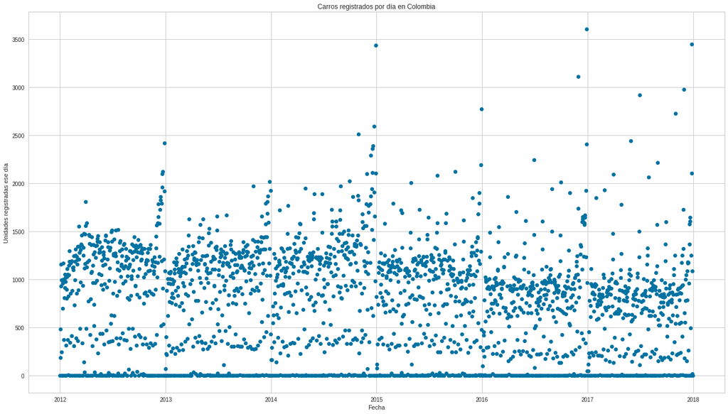

```python
x=data['Fecha']
y=data['Unidades']
plt.plot_date(x, y)
plt.gcf().set_size_inches(18, 10)
plt.tight_layout()
plt.title("Carros registrados por día en Colombia")
plt.xlabel("Fecha")
plt.ylabel("Unidades registradas ese día")
plt.show()
```

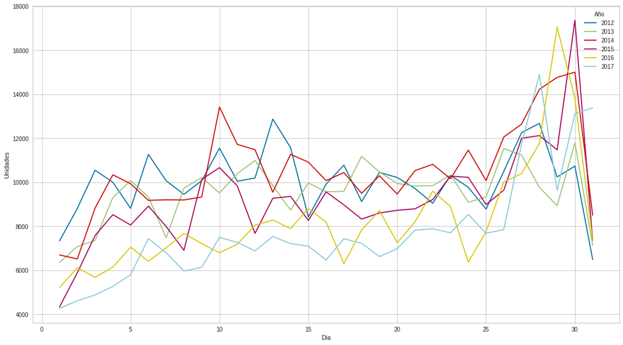

```python
ax2= diaxyear.plot.line()
plt.ylabel("Unidades")
plt.xlabel("Dia")
plt.gcf().set_size_inches(18, 10)
plt.legend(['2012','2013','2014','2015','2016','2017'],title='Año')
```

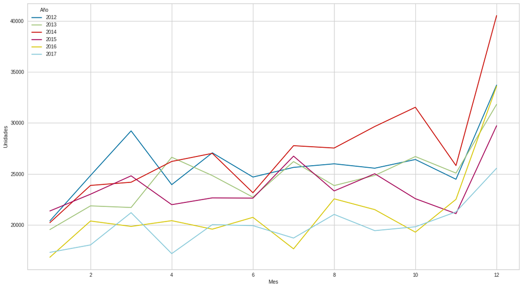

```python
ax3= mesxyear.plot.line()
plt.ylabel("Unidades")
plt.xlabel("Mes")
plt.gcf().set_size_inches(18, 10)
plt.legend(['2012','2013','2014','2015','2016','2017'],title='Año')
```

La variable explicativa es la Fecha y la de respuesta son las unidades, esto es porque las unidades se predicen a partir de la fecha y no al revés, lo que significa que la variable independiente sea la fecha.

# Modelos

Extraemos los datos que servirán para el entrenamiento de los modelos, así como para la validación correspondientes a:

- X_train: Entrenamiento: toda la información hasta el 31 de diciembre de 2016
- X_test: Validación: el año 2017

```python
X_train = data[data['Fecha'] < '2017-01-01']
X_train = X_train[['Year',	'Mes',	'Dia',	'DiaNom', 'Unidades']]
X_train
```

|  | Year | Mes | Dia | DiaNom | Unidades |
| --- | --- | --- | --- | --- | --- |
| 0 | 2012 | 1 | 1 | Sunday | 0.0 |
| 1 | 2012 | 1 | 2 | Monday | 188.0 |
| 2 | 2012 | 1 | 3 | Tuesday | 482.0 |
| 3 | 2012 | 1 | 4 | Wednesday | 927.0 |
| 4 | 2012 | 1 | 5 | Thursday | 1159.0 |
| ... | ... | ... | ... | ... | ... |
| 1822 | 2016 | 12 | 27 | Tuesday | 1922.0 |
| 1823 | 2016 | 12 | 28 | Wednesday | 2409.0 |
| 1824 | 2016 | 12 | 29 | Thursday | 3603.0 |
| 1825 | 2016 | 12 | 30 | Friday | 965.0 |
| 1826 | 2016 | 12 | 31 | Saturday | 46.0 |

1827 rows × 5 columns

```python
X_test = data[data['Fecha'] >= '2017-01-01']
X_test = X_test[['Year',	'Mes',	'Dia',	'DiaNom', 'Unidades']]
X_test.reset_index(inplace = True)
X_test =  X_test.drop(['index'], axis = 1)
X_test
```

|  | Year | Mes | Dia | DiaNom | Unidades |
| --- | --- | --- | --- | --- | --- |
| 0 | 2017 | 1 | 1 | Sunday | 0.0 |
| 1 | 2017 | 1 | 2 | Monday | 45.0 |
| 2 | 2017 | 1 | 3 | Tuesday | 116.0 |
| 3 | 2017 | 1 | 4 | Wednesday | 232.0 |
| 4 | 2017 | 1 | 5 | Thursday | 455.0 |
| ... | ... | ... | ... | ... | ... |
| 360 | 2017 | 12 | 27 | Wednesday | 2102.0 |
| 361 | 2017 | 12 | 28 | Thursday | 3449.0 |
| 362 | 2017 | 12 | 29 | Friday | 1084.0 |
| 363 | 2017 | 12 | 30 | Saturday | 18.0 |
| 364 | 2017 | 12 | 31 | Sunday | 0.0 |

365 rows × 5 columns

Creamos columnas dummies para un mejor entrenamiento de los modelos

```python
X_train = pd.get_dummies(X_train)
X_train
```

|  | Year | Mes | Dia | Unidades | DiaNom_Friday | DiaNom_Monday | DiaNom_Saturday | DiaNom_Sunday | DiaNom_Thursday | DiaNom_Tuesday | DiaNom_Wednesday |
| --- | --- | --- | --- | --- | --- | --- | --- | --- | --- | --- | --- |
| 0 | 2012 | 1 | 1 | 0.0 | 0 | 0 | 0 | 1 | 0 | 0 | 0 |
| 1 | 2012 | 1 | 2 | 188.0 | 0 | 1 | 0 | 0 | 0 | 0 | 0 |
| 2 | 2012 | 1 | 3 | 482.0 | 0 | 0 | 0 | 0 | 0 | 1 | 0 |
| 3 | 2012 | 1 | 4 | 927.0 | 0 | 0 | 0 | 0 | 0 | 0 | 1 |
| 4 | 2012 | 1 | 5 | 1159.0 | 0 | 0 | 0 | 0 | 1 | 0 | 0 |
| ... | ... | ... | ... | ... | ... | ... | ... | ... | ... | ... | ... |
| 1822 | 2016 | 12 | 27 | 1922.0 | 0 | 0 | 0 | 0 | 0 | 1 | 0 |
| 1823 | 2016 | 12 | 28 | 2409.0 | 0 | 0 | 0 | 0 | 0 | 0 | 1 |
| 1824 | 2016 | 12 | 29 | 3603.0 | 0 | 0 | 0 | 0 | 1 | 0 | 0 |
| 1825 | 2016 | 12 | 30 | 965.0 | 1 | 0 | 0 | 0 | 0 | 0 | 0 |
| 1826 | 2016 | 12 | 31 | 46.0 | 0 | 0 | 1 | 0 | 0 | 0 | 0 |

1827 rows × 11 columns

```python
X_test = pd.get_dummies(X_test)
X_test
```

|  | Year | Mes | Dia | Unidades | DiaNom_Friday | DiaNom_Monday | DiaNom_Saturday | DiaNom_Sunday | DiaNom_Thursday | DiaNom_Tuesday | DiaNom_Wednesday |
| --- | --- | --- | --- | --- | --- | --- | --- | --- | --- | --- | --- |
| 0 | 2017 | 1 | 1 | 0.0 | 0 | 0 | 0 | 1 | 0 | 0 | 0 |
| 1 | 2017 | 1 | 2 | 45.0 | 0 | 1 | 0 | 0 | 0 | 0 | 0 |
| 2 | 2017 | 1 | 3 | 116.0 | 0 | 0 | 0 | 0 | 0 | 1 | 0 |
| 3 | 2017 | 1 | 4 | 232.0 | 0 | 0 | 0 | 0 | 0 | 0 | 1 |
| 4 | 2017 | 1 | 5 | 455.0 | 0 | 0 | 0 | 0 | 1 | 0 | 0 |
| ... | ... | ... | ... | ... | ... | ... | ... | ... | ... | ... | ... |
| 360 | 2017 | 12 | 27 | 2102.0 | 0 | 0 | 0 | 0 | 0 | 0 | 1 |
| 361 | 2017 | 12 | 28 | 3449.0 | 0 | 0 | 0 | 0 | 1 | 0 | 0 |
| 362 | 2017 | 12 | 29 | 1084.0 | 1 | 0 | 0 | 0 | 0 | 0 | 0 |
| 363 | 2017 | 12 | 30 | 18.0 | 0 | 0 | 1 | 0 | 0 | 0 | 0 |
| 364 | 2017 | 12 | 31 | 0.0 | 0 | 0 | 0 | 1 | 0 | 0 | 0 |

365 rows × 11 columns

```python
numerico = list(X_train.columns.values)
numerico.remove('Unidades')
numerico
```

```
['Year',
 'Mes',
 'Dia',
 'DiaNom_Friday',
 'DiaNom_Monday',
 'DiaNom_Saturday',
 'DiaNom_Sunday',
 'DiaNom_Thursday',
 'DiaNom_Tuesday',
 'DiaNom_Wednesday']
```

```python
comparar = setup(data = X_train, target = 'Unidades', numeric_features = numerico , normalize = True, session_id = 1234)
```

|  | Description | Value |
| --- | --- | --- |
| 0 | Session id | 1234 |
| 1 | Target | Unidades |
| 2 | Target type | Regression |
| 3 | Data shape | (1827, 11) |
| 4 | Train data shape | (1278, 11) |
| 5 | Test data shape | (549, 11) |
| 6 | Numeric features | 10 |
| 7 | Preprocess | True |
| 8 | Imputation type | simple |
| 9 | Numeric imputation | mean |
| 10 | Categorical imputation | constant |
| 11 | Normalize | True |
| 12 | Normalize method | zscore |
| 13 | Fold Generator | KFold |
| 14 | Fold Number | 10 |
| 15 | CPU Jobs | -1 |
| 16 | Use GPU | False |
| 17 | Log Experiment | False |
| 18 | Experiment Name | reg-default-name |
| 19 | USI | 1d7f |

```python
compare_models()
```

|  | Model | MAE | MSE | RMSE | R2 | RMSLE | MAPE | TT (Sec) |
| --- | --- | --- | --- | --- | --- | --- | --- | --- |
| lightgbm | Light Gradient Boosting Machine | 146.0621 | 57825.4765 | 239.1899 | 0.7946 | 1.6920 | 3.2066 | 0.0930 |
| gbr | Gradient Boosting Regressor | 145.4997 | 58921.6466 | 240.6337 | 0.7920 | 1.6957 | 4.0065 | 0.0940 |
| rf | Random Forest Regressor | 140.8155 | 61091.5981 | 245.5527 | 0.7822 | 1.3462 | 1.6546 | 0.3510 |
| et | Extra Trees Regressor | 151.7853 | 69510.0442 | 261.6779 | 0.7527 | 1.3657 | 1.6695 | 0.2970 |
| knn | K Neighbors Regressor | 172.4492 | 77274.6656 | 275.7592 | 0.7249 | 1.3618 | 1.5856 | 0.0760 |
| ridge | Ridge Regression | 190.9679 | 81364.4251 | 283.3627 | 0.7114 | 1.9249 | 5.2445 | 0.0290 |
| lar | Least Angle Regression | 190.9861 | 81365.1059 | 283.3629 | 0.7114 | 1.9252 | 5.2450 | 0.0330 |
| br | Bayesian Ridge | 190.9154 | 81364.3208 | 283.3655 | 0.7114 | 1.9243 | 5.2429 | 0.0290 |
| lasso | Lasso Regression | 190.6957 | 81374.2133 | 283.3862 | 0.7113 | 1.9221 | 5.2152 | 0.0300 |
| lr | Linear Regression | 191.2623 | 81506.3601 | 283.6266 | 0.7108 | 1.9250 | 5.2328 | 0.4770 |
| huber | Huber Regressor | 182.2093 | 83910.8248 | 287.8173 | 0.7026 | 1.8490 | 4.0050 | 0.0340 |
| par | Passive Aggressive Regressor | 184.8597 | 87041.1649 | 293.2155 | 0.6916 | 1.8025 | 3.6805 | 0.0320 |
| llar | Lasso Least Angle Regression | 201.8404 | 90977.7270 | 300.1479 | 0.6773 | 1.9212 | 5.2353 | 0.0300 |
| en | Elastic Net | 228.9927 | 99911.8404 | 314.8813 | 0.6450 | 2.2214 | 11.3856 | 0.0290 |
| dt | Decision Tree Regressor | 177.2107 | 101934.6169 | 317.5948 | 0.6372 | 1.7227 | 1.5430 | 0.0310 |
| ada | AdaBoost Regressor | 330.6355 | 157847.8481 | 396.1032 | 0.4356 | 2.2659 | 18.6793 | 0.0980 |
| omp | Orthogonal Matching Pursuit | 307.6196 | 178382.9349 | 421.4790 | 0.3624 | 1.4850 | 3.1564 | 0.0300 |
| dummy | Dummy Regressor | 444.2920 | 282281.7812 | 530.8295 | -0.0069 | 2.6393 | 35.1975 | 0.0290 |

```
LGBMRegressor(random_state=1234)
```

## Modelo Light Gradient Boosting Machine (lightgbm)

Realizaremos los siguientes procedimientos en y para comprar los 4 primeros modelos resultantes de la tabla anterior, los cuales entrenaremos, mejoraremos y exportaremos.

```python
mlightgbm = create_model('lightgbm')
```

| Fold | MAE | MSE | RMSE | R2 | RMSLE | MAPE |
| --- | --- | --- | --- | --- | --- | --- |
| 0 | 148.4278 | 59062.9405 | 243.0287 | 0.7714 | 1.4752 | 3.5491 |
| 1 | 158.2969 | 65812.0460 | 256.5386 | 0.7606 | 1.6933 | 6.4943 |
| 2 | 149.6108 | 55283.6179 | 235.1247 | 0.7934 | 1.4777 | 0.8059 |
| 3 | 137.1840 | 63601.9376 | 252.1942 | 0.8060 | 1.6517 | 1.0117 |
| 4 | 169.0430 | 83555.9632 | 289.0605 | 0.7299 | 2.2432 | 4.3575 |
| 5 | 137.2264 | 48684.4095 | 220.6454 | 0.8171 | 1.6555 | 3.2936 |
| 6 | 139.9446 | 47517.4430 | 217.9850 | 0.8310 | 1.7224 | 4.0909 |
| 7 | 156.2194 | 65018.0300 | 254.9863 | 0.7886 | 1.7247 | 2.8979 |
| 8 | 132.6315 | 51766.1010 | 227.5216 | 0.7947 | 1.7686 | 2.1212 |
| 9 | 132.0363 | 37952.2764 | 194.8134 | 0.8533 | 1.5078 | 3.4442 |
| Mean | 146.0621 | 57825.4765 | 239.1899 | 0.7946 | 1.6920 | 3.2066 |
| Std | 11.7072 | 12001.7111 | 24.7728 | 0.0337 | 0.2101 | 1.5796 |

Para mejorar este modelo, es decir, obtener los hiperparámetros óptimos o que más se aproximan a estos, podemos correr la siguiente función, que entrena 10 modelos distintos 10 veces cada uno, y devuelve el que mejor precisión media obtenga:

```python
tuned_mlightgbm = tune_model(mlightgbm)
```

| Fold | MAE | MSE | RMSE | R2 | RMSLE | MAPE |
| --- | --- | --- | --- | --- | --- | --- |
| 0 | 163.4041 | 64436.0579 | 253.8426 | 0.7506 | 1.5818 | 4.9949 |
| 1 | 174.4599 | 69862.8041 | 264.3157 | 0.7459 | 1.8543 | 10.4550 |
| 2 | 159.3325 | 56504.4890 | 237.7067 | 0.7889 | 1.5766 | 1.5825 |
| 3 | 151.3737 | 71992.6041 | 268.3144 | 0.7804 | 1.8281 | 1.2666 |
| 4 | 179.1016 | 90092.6057 | 300.1543 | 0.7087 | 2.3579 | 9.2511 |
| 5 | 151.2301 | 50443.5570 | 224.5964 | 0.8105 | 1.8059 | 5.3837 |
| 6 | 151.8925 | 57096.4500 | 238.9486 | 0.7970 | 1.8485 | 5.8109 |
| 7 | 171.6694 | 74075.1980 | 272.1676 | 0.7591 | 1.9218 | 3.8221 |
| 8 | 150.3889 | 56956.2624 | 238.6551 | 0.7741 | 1.9681 | 4.1458 |
| 9 | 147.7497 | 45138.1228 | 212.4573 | 0.8256 | 1.5725 | 3.2866 |
| Mean | 160.0602 | 63659.8151 | 251.1159 | 0.7741 | 1.8316 | 4.9999 |
| Std | 10.8703 | 12540.4316 | 24.5077 | 0.0326 | 0.2236 | 2.8161 |

```
Fitting 10 folds for each of 10 candidates, totalling 100 fits
```

```
Original model was better than the tuned model, hence it will be returned. NOTE: The display metrics are for the tuned model (not the original one).
```

Podemos visualizar las variables, para poder obtener conclusiones sobre las variables que más afectan a nuestra variable objetivo:

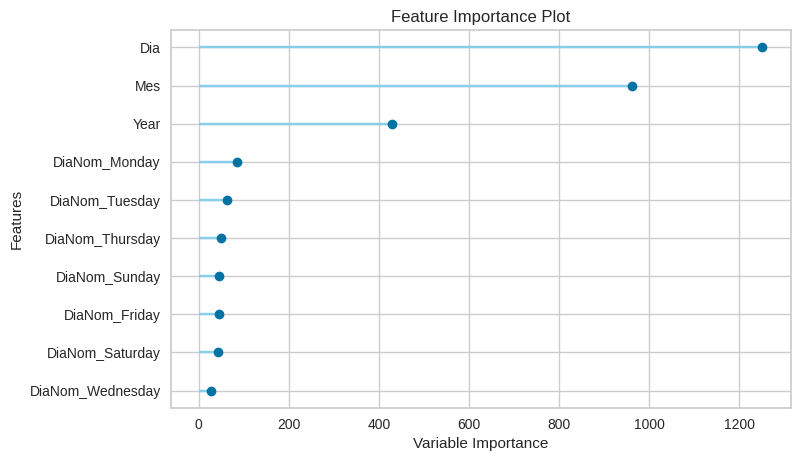

```python
plot_model(tuned_mlightgbm, plot='feature')
```

```python
X_train_predict = X_train.drop(['Unidades'], axis = 1)
```

```python
Y_train_lightgbm = predict_model(tuned_mlightgbm, data = X_train_predict)
```

```python
# Función para calcular el MAE Mean Absolute Error

def MAE(y_true, predictions):
    y_true, predictions = np.array(y_true), np.array(predictions)
    return np.mean(np.abs(y_true - predictions))
```

Ahora se observa el MSE, MAE y R2 para los datos de entrenamiento (que posee los días comprendidos entre el 01/01/2012 y el 31/12/2016)

```python
compare_models_train = pd.DataFrame([['lightgbm',  MSE(X_train['Unidades'], Y_train_lightgbm['Label']),
                                            MAE(X_train['Unidades'], Y_train_lightgbm['Label']),
                                            R2(X_train['Unidades'], Y_train_lightgbm['Label'])]], columns = ['Nombre', 'MSE', 'MAE', 'R2'])
compare_models_train
```

|  | Nombre | MSE | MAE | R2 |
| --- | --- | --- | --- | --- |
| 0 | lightgbm | 44797.886543 | 119.897172 | 0.852988 |

De igual forma para los datos de validación

```python
X_test_predict = X_test.drop(['Unidades'], axis = 1)
```

```python
Y_test_lightgbm = predict_model(tuned_mlightgbm, data = X_test_predict)
```

```python
compare_models_test = pd.DataFrame([['lightgbm',  MSE(X_test['Unidades'], Y_test_lightgbm['Label']),
                                            MAE(X_test['Unidades'], Y_test_lightgbm['Label']),
                                            R2(X_test['Unidades'], Y_test_lightgbm['Label'])]], columns = ['Nombre', 'MSE', 'MAE', 'R2'])
compare_models_test
```

|  | Nombre | MSE | MAE | R2 |
| --- | --- | --- | --- | --- |
| 0 | lightgbm | 58967.178009 | 135.98259 | 0.788792 |

Por último guardamos el modelo

```python
# joblib.dump(tuned_mlightgbm, 'modelo_lightgbm.pkl')
```

## Modelo Gradient Boosting Regressor (gbr)

```python
mgbr = create_model('gbr')
```

| Fold | MAE | MSE | RMSE | R2 | RMSLE | MAPE |
| --- | --- | --- | --- | --- | --- | --- |
| 0 | 154.8058 | 65503.4526 | 255.9364 | 0.7465 | 1.4112 | 3.7510 |
| 1 | 160.5550 | 65870.7903 | 256.6531 | 0.7604 | 1.7626 | 10.2518 |
| 2 | 133.0594 | 42845.2699 | 206.9910 | 0.8399 | 1.3334 | 0.2862 |
| 3 | 142.8704 | 73972.1006 | 271.9781 | 0.7743 | 1.6984 | 0.9906 |
| 4 | 176.0650 | 88164.7390 | 296.9255 | 0.7150 | 2.2248 | 7.1060 |
| 5 | 133.8917 | 48978.3357 | 221.3105 | 0.8160 | 1.6409 | 4.1903 |
| 6 | 144.3802 | 52503.2422 | 229.1359 | 0.8133 | 1.7761 | 5.5415 |
| 7 | 154.0300 | 70850.9763 | 266.1785 | 0.7696 | 1.8606 | 2.6696 |
| 8 | 131.2376 | 41954.4866 | 204.8279 | 0.8336 | 1.7901 | 1.6972 |
| 9 | 124.1015 | 38573.0732 | 196.4003 | 0.8509 | 1.4592 | 3.5805 |
| Mean | 145.4997 | 58921.6466 | 240.6337 | 0.7920 | 1.6957 | 4.0065 |
| Std | 15.0971 | 15543.6755 | 31.8914 | 0.0428 | 0.2446 | 2.8514 |

Mejoramos el modelo

```python
tuned_mgbr = tune_model(mgbr)
```

| Fold | MAE | MSE | RMSE | R2 | RMSLE | MAPE |
| --- | --- | --- | --- | --- | --- | --- |
| 0 | 152.6316 | 64495.6437 | 253.9599 | 0.7504 | 1.4706 | 4.7187 |
| 1 | 169.7755 | 70702.3742 | 265.8992 | 0.7428 | 1.8723 | 13.8193 |
| 2 | 142.8416 | 47376.2910 | 217.6610 | 0.8230 | 1.5547 | 1.0931 |
| 3 | 147.5639 | 70705.6141 | 265.9053 | 0.7843 | 1.9250 | 2.3037 |
| 4 | 179.4465 | 93377.3018 | 305.5770 | 0.6981 | 2.4059 | 13.7683 |
| 5 | 147.0746 | 55433.8566 | 235.4440 | 0.7918 | 1.8438 | 5.4685 |
| 6 | 146.5558 | 54174.0448 | 232.7532 | 0.8074 | 1.8088 | 6.2019 |
| 7 | 167.3657 | 83323.4107 | 288.6579 | 0.7291 | 1.9517 | 5.4530 |
| 8 | 148.0998 | 48770.6640 | 220.8408 | 0.8066 | 1.9505 | 6.0819 |
| 9 | 141.3933 | 48521.1479 | 220.2752 | 0.8125 | 1.6211 | 4.4876 |
| Mean | 154.2748 | 63688.0349 | 250.6973 | 0.7746 | 1.8404 | 6.3396 |
| Std | 12.4065 | 14977.9272 | 28.9634 | 0.0397 | 0.2490 | 4.0328 |

```
Fitting 10 folds for each of 10 candidates, totalling 100 fits
```

```
Original model was better than the tuned model, hence it will be returned. NOTE: The display metrics are for the tuned model (not the original one).
```

Variables relavantes del modelo

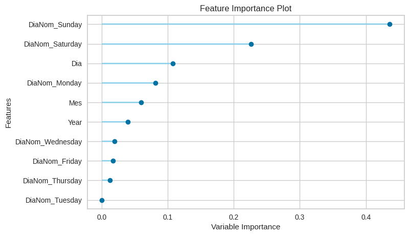

```python
plot_model(tuned_mgbr, plot='feature')
```

Hacemos la predicción haciendo uso del modelo para los datos de entrenamiento

```python
Y_train_gbr = predict_model(tuned_mgbr, data = X_train_predict)
```

Camparamos los dos modelos actuales

```python
compare_gbr = {'Nombre': 'gbr',
               'MSE': MSE(X_train['Unidades'], Y_train_gbr['Label']),
               'MAE': MAE(X_train['Unidades'], Y_train_gbr['Label']),
               'R2': R2(X_train['Unidades'], Y_train_gbr['Label'])}

compare_models_train = compare_models_train.append(compare_gbr, ignore_index=True)
```

```python
compare_models_train.sort_values('R2', ascending=False)
```

|  | Nombre | MSE | MAE | R2 |
| --- | --- | --- | --- | --- |
| 0 | lightgbm | 44797.886543 | 119.897172 | 0.852988 |
| 1 | gbr | 57607.048091 | 140.626122 | 0.810953 |

Comparación para la predicción de la validación

```python
Y_test_gbr = predict_model(tuned_mgbr, data = X_test_predict)
```

```python
compare_gbr = {'Nombre': 'gbr',
               'MSE': MSE(X_test['Unidades'], Y_test_gbr['Label']),
               'MAE': MAE(X_test['Unidades'], Y_test_gbr['Label']),
               'R2': R2(X_test['Unidades'], Y_test_gbr['Label'])}

compare_models_test = compare_models_test.append(compare_gbr, ignore_index=True)
```

```python
compare_models_test.sort_values('R2', ascending=False)
```

|  | Nombre | MSE | MAE | R2 |
| --- | --- | --- | --- | --- |
| 0 | lightgbm | 58967.178009 | 135.982590 | 0.788792 |
| 1 | gbr | 69374.317975 | 156.368526 | 0.751516 |

Por último se exporta el modelo

```python
# joblib.dump(tuned_mgbr, 'modelo_gbr.pkl')
```

## Modelo Random Forest Regressor (rf)

```python
mrf = create_model('rf')
```

| Fold | MAE | MSE | RMSE | R2 | RMSLE | MAPE |
| --- | --- | --- | --- | --- | --- | --- |
| 0 | 147.8189 | 66545.4534 | 257.9641 | 0.7424 | 1.2419 | 2.4838 |
| 1 | 159.0520 | 71276.9998 | 266.9775 | 0.7407 | 1.4544 | 3.5088 |
| 2 | 156.2930 | 68464.5785 | 261.6574 | 0.7442 | 1.1299 | 0.2172 |
| 3 | 132.5536 | 65268.6324 | 255.4773 | 0.8009 | 1.2478 | 0.2519 |
| 4 | 158.5752 | 84418.5974 | 290.5488 | 0.7271 | 1.7736 | 0.7581 |
| 5 | 123.6131 | 44781.5495 | 211.6165 | 0.8318 | 1.3263 | 2.0901 |
| 6 | 132.6963 | 47788.3180 | 218.6054 | 0.8301 | 1.4974 | 4.1180 |
| 7 | 142.1677 | 62625.0029 | 250.2499 | 0.7964 | 1.2926 | 0.6728 |
| 8 | 130.9693 | 63419.2672 | 251.8318 | 0.7485 | 1.3761 | 0.5721 |
| 9 | 124.4158 | 36327.5821 | 190.5980 | 0.8596 | 1.1223 | 1.8731 |
| Mean | 140.8155 | 61091.5981 | 245.5527 | 0.7822 | 1.3462 | 1.6546 |
| Std | 13.1697 | 13466.4959 | 28.2044 | 0.0450 | 0.1841 | 1.3193 |

Mejora del modelo

```python
tuned_mrf = tune_model(mrf)
```

| Fold | MAE | MSE | RMSE | R2 | RMSLE | MAPE |
| --- | --- | --- | --- | --- | --- | --- |
| 0 | 158.0838 | 72346.6266 | 268.9733 | 0.7200 | 1.2829 | 3.0683 |
| 1 | 188.3595 | 89373.0530 | 298.9533 | 0.6749 | 1.5953 | 4.2301 |
| 2 | 154.4227 | 62406.0357 | 249.8120 | 0.7668 | 1.2052 | 0.2038 |
| 3 | 149.6412 | 86284.6527 | 293.7425 | 0.7368 | 1.3395 | 0.5017 |
| 4 | 175.3769 | 99736.9458 | 315.8116 | 0.6776 | 1.8970 | 1.3739 |
| 5 | 131.5575 | 52569.8798 | 229.2812 | 0.8025 | 1.3594 | 2.3942 |
| 6 | 149.4388 | 63136.7777 | 251.2703 | 0.7755 | 1.5718 | 3.9988 |
| 7 | 150.8204 | 70426.7923 | 265.3805 | 0.7710 | 1.5121 | 0.8588 |
| 8 | 128.8098 | 54992.5378 | 234.5049 | 0.7819 | 1.4418 | 0.6637 |
| 9 | 127.9382 | 43614.1021 | 208.8399 | 0.8315 | 1.2319 | 2.2600 |
| Mean | 151.4449 | 69488.7404 | 261.6569 | 0.7538 | 1.4437 | 1.9553 |
| Std | 18.5916 | 16905.2853 | 32.0060 | 0.0486 | 0.1988 | 1.3880 |

```
Fitting 10 folds for each of 10 candidates, totalling 100 fits
```

```
Original model was better than the tuned model, hence it will be returned. NOTE: The display metrics are for the tuned model (not the original one).
```

Relavancia de las variables

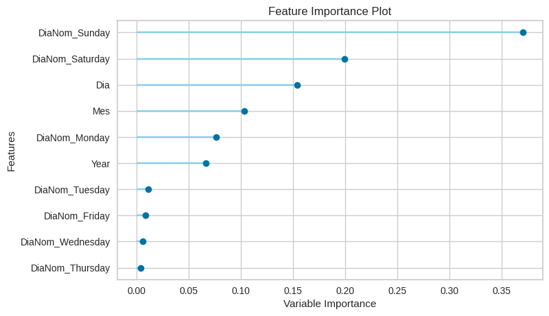

```python
plot_model(tuned_mrf, plot='feature')
```

Predicción para los datos de entrenamiento

```python
Y_train_rf = predict_model(tuned_mrf, data = X_train_predict)
```

```python
compare_rf = {'Nombre': 'rf',
               'MSE': MSE(X_train['Unidades'], Y_train_rf['Label']),
               'MAE': MAE(X_train['Unidades'], Y_train_rf['Label']),
               'R2': R2(X_train['Unidades'], Y_train_rf['Label'])}

compare_models_train = compare_models_train.append(compare_rf, ignore_index=True)
```

```python
compare_models_train.sort_values(['R2'], ascending = False)
```

|  | Nombre | MSE | MAE | R2 |
| --- | --- | --- | --- | --- |
| 2 | rf | 33109.017116 | 87.791297 | 0.891347 |
| 0 | lightgbm | 44797.886543 | 119.897172 | 0.852988 |
| 1 | gbr | 57607.048091 | 140.626122 | 0.810953 |

Predicción para los datos de validación

```python
Y_test_rf = predict_model(tuned_mrf, data = X_test_predict)
```

```python
compare_rf = {'Nombre': 'rf',
               'MSE': MSE(X_test['Unidades'], Y_test_rf['Label']),
               'MAE': MAE(X_test['Unidades'], Y_test_rf['Label']),
               'R2': R2(X_test['Unidades'], Y_test_rf['Label'])}

compare_models_test = compare_models_test.append(compare_rf, ignore_index=True)
```

```python
compare_models_test.sort_values(['R2'], ascending = False)
```

|  | Nombre | MSE | MAE | R2 |
| --- | --- | --- | --- | --- |
| 0 | lightgbm | 58967.178009 | 135.982590 | 0.788792 |
| 2 | rf | 62669.971384 | 139.818329 | 0.775530 |
| 1 | gbr | 69374.317975 | 156.368526 | 0.751516 |

```python
# joblib.dump(tuned_mgbr, 'modelo_rf.pkl')
```

## Modelo Extra Trees Regressor (et)

```python
met = create_model('et')
```

| Fold | MAE | MSE | RMSE | R2 | RMSLE | MAPE |
| --- | --- | --- | --- | --- | --- | --- |
| 0 | 161.1589 | 78006.9119 | 279.2972 | 0.6981 | 1.2653 | 2.6720 |
| 1 | 176.1734 | 79169.2137 | 281.3702 | 0.7120 | 1.4904 | 3.3544 |
| 2 | 160.3268 | 68544.8892 | 261.8108 | 0.7439 | 1.1374 | 0.2204 |
| 3 | 138.2226 | 75149.0916 | 274.1333 | 0.7707 | 1.2902 | 0.2506 |
| 4 | 175.0511 | 97088.2234 | 311.5898 | 0.6861 | 1.7613 | 0.7281 |
| 5 | 140.5377 | 56056.6341 | 236.7628 | 0.7894 | 1.3488 | 2.3892 |
| 6 | 145.8802 | 57956.6034 | 240.7418 | 0.7939 | 1.5203 | 3.7921 |
| 7 | 156.8761 | 77701.5089 | 278.7499 | 0.7473 | 1.3102 | 0.7287 |
| 8 | 142.8193 | 70606.1384 | 265.7182 | 0.7200 | 1.3941 | 0.6178 |
| 9 | 120.8072 | 34821.2278 | 186.6045 | 0.8654 | 1.1385 | 1.9413 |
| Mean | 151.7853 | 69510.0442 | 261.6779 | 0.7527 | 1.3657 | 1.6695 |
| Std | 16.4565 | 15952.6625 | 32.1675 | 0.0513 | 0.1788 | 1.2622 |

Mejora del modelo

```python
tuned_met = tune_model(met)
```

| Fold | MAE | MSE | RMSE | R2 | RMSLE | MAPE |
| --- | --- | --- | --- | --- | --- | --- |
| 0 | 182.2859 | 83289.5351 | 288.5993 | 0.6776 | 1.3042 | 2.6405 |
| 1 | 197.5480 | 96672.3753 | 310.9218 | 0.6484 | 1.5671 | 3.8947 |
| 2 | 163.3452 | 72437.6981 | 269.1425 | 0.7294 | 1.2216 | 0.3004 |
| 3 | 164.3036 | 93599.0124 | 305.9396 | 0.7145 | 1.4958 | 0.8892 |
| 4 | 184.0402 | 102567.2495 | 320.2612 | 0.6684 | 1.8906 | 1.2048 |
| 5 | 151.8129 | 59984.5520 | 244.9174 | 0.7747 | 1.4144 | 2.4093 |
| 6 | 160.9022 | 65300.9875 | 255.5406 | 0.7678 | 1.5772 | 4.1139 |
| 7 | 161.2665 | 76526.5963 | 276.6344 | 0.7512 | 1.4502 | 0.9785 |
| 8 | 135.0543 | 54687.6632 | 233.8539 | 0.7831 | 1.4308 | 0.5802 |
| 9 | 137.1766 | 46278.8041 | 215.1251 | 0.8212 | 1.2212 | 1.8512 |
| Mean | 163.7735 | 75134.4473 | 272.0936 | 0.7336 | 1.4573 | 1.8863 |
| Std | 18.9325 | 17916.5636 | 33.1592 | 0.0532 | 0.1879 | 1.2784 |

```
Fitting 10 folds for each of 10 candidates, totalling 100 fits
```

```
Original model was better than the tuned model, hence it will be returned. NOTE: The display metrics are for the tuned model (not the original one).
```

Variables relevantes del modelo

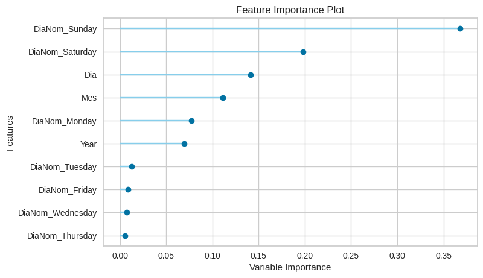

```python
plot_model(tuned_met, plot='feature')
```

Predicción para los datos de entrenamiento

```python
Y_train_et = predict_model(tuned_met, data = X_train_predict)
```

```python
compare_et = {'Nombre': 'et',
               'MSE': MSE(X_train['Unidades'], Y_train_et['Label']),
               'MAE': MAE(X_train['Unidades'], Y_train_et['Label']),
               'R2': R2(X_train['Unidades'], Y_train_et['Label'])}

compare_models_train = compare_models_train.append(compare_et, ignore_index=True)
```

```python
compare_models_train.sort_values(['R2'], ascending = False)
```

|  | Nombre | MSE | MAE | R2 |
| --- | --- | --- | --- | --- |
| 3 | et | 30722.753961 | 54.555041 | 0.899178 |
| 2 | rf | 33109.017116 | 87.791297 | 0.891347 |
| 0 | lightgbm | 44797.886543 | 119.897172 | 0.852988 |
| 1 | gbr | 57607.048091 | 140.626122 | 0.810953 |

Predicción para los datos de validación

```python
Y_test_et = predict_model(tuned_met, data = X_test_predict)
```

```python
compare_et = {'Nombre': 'et',
               'MSE': MSE(X_test['Unidades'], Y_test_et['Label']),
               'MAE': MAE(X_test['Unidades'], Y_test_et['Label']),
               'R2': R2(X_test['Unidades'], Y_test_et['Label'])}

compare_models_test = compare_models_test.append(compare_et, ignore_index=True)
```

```python
compare_models_test.sort_values(['R2'], ascending = False)
```

|  | Nombre | MSE | MAE | R2 |
| --- | --- | --- | --- | --- |
| 0 | lightgbm | 58967.178009 | 135.982590 | 0.788792 |
| 2 | rf | 62669.971384 | 139.818329 | 0.775530 |
| 1 | gbr | 69374.317975 | 156.368526 | 0.751516 |
| 3 | et | 69581.403925 | 144.397425 | 0.750775 |

## Comparación de los modelos

La comparación se ha ido mostrando a medida que se usa un nuevo modelo, sin embargo, aquí están los resultados.

Para los datos de entrenamiento y la comparación de los modelos entrenados y mejorados:

```python
compare_models_train.sort_values(['R2'], ascending = False)
```

|  | Nombre | MSE | MAE | R2 |
| --- | --- | --- | --- | --- |
| 3 | et | 30722.753961 | 54.555041 | 0.899178 |
| 2 | rf | 33109.017116 | 87.791297 | 0.891347 |
| 0 | lightgbm | 44797.886543 | 119.897172 | 0.852988 |
| 1 | gbr | 57607.048091 | 140.626122 | 0.810953 |

Para los datos de validación e igualmente la comparación de los modelos entrenados y mejorados:

```python
compare_models_test.sort_values(['R2'], ascending = False)
```

|  | Nombre | MSE | MAE | R2 |
| --- | --- | --- | --- | --- |
| 0 | lightgbm | 58967.178009 | 135.982590 | 0.788792 |
| 2 | rf | 62669.971384 | 139.818329 | 0.775530 |
| 1 | gbr | 69374.317975 | 156.368526 | 0.751516 |
| 3 | et | 69581.403925 | 144.397425 | 0.750775 |

## Generación y exportación de textos planos

Como la idea es predecir los valores de las fechas comprendidas en el primer semestre del año 2018, realizaremos el entrenamiento nuevamente con todo el dataset proporcionado.

```python
datadates = data['Fecha']
data.drop(['Fecha'], axis=1, inplace = True)
```

```python
data = pd.get_dummies(data)
data
```

|  | Unidades | Year | Mes | Dia | DiaNom_Friday | DiaNom_Monday | DiaNom_Saturday | DiaNom_Sunday | DiaNom_Thursday | DiaNom_Tuesday | DiaNom_Wednesday |
| --- | --- | --- | --- | --- | --- | --- | --- | --- | --- | --- | --- |
| 0 | 0.0 | 2012 | 1 | 1 | 0 | 0 | 0 | 1 | 0 | 0 | 0 |
| 1 | 188.0 | 2012 | 1 | 2 | 0 | 1 | 0 | 0 | 0 | 0 | 0 |
| 2 | 482.0 | 2012 | 1 | 3 | 0 | 0 | 0 | 0 | 0 | 1 | 0 |
| 3 | 927.0 | 2012 | 1 | 4 | 0 | 0 | 0 | 0 | 0 | 0 | 1 |
| 4 | 1159.0 | 2012 | 1 | 5 | 0 | 0 | 0 | 0 | 1 | 0 | 0 |
| ... | ... | ... | ... | ... | ... | ... | ... | ... | ... | ... | ... |
| 2187 | 2102.0 | 2017 | 12 | 27 | 0 | 0 | 0 | 0 | 0 | 0 | 1 |
| 2188 | 3449.0 | 2017 | 12 | 28 | 0 | 0 | 0 | 0 | 1 | 0 | 0 |
| 2189 | 1084.0 | 2017 | 12 | 29 | 1 | 0 | 0 | 0 | 0 | 0 | 0 |
| 2190 | 18.0 | 2017 | 12 | 30 | 0 | 0 | 1 | 0 | 0 | 0 | 0 |
| 2191 | 0.0 | 2017 | 12 | 31 | 0 | 0 | 0 | 1 | 0 | 0 | 0 |

2192 rows × 11 columns

```python
setup(data = data, target = 'Unidades', numeric_features = numerico , normalize = True, session_id = 1234)
```

|  | Description | Value |
| --- | --- | --- |
| 0 | Session id | 1234 |
| 1 | Target | Unidades |
| 2 | Target type | Regression |
| 3 | Data shape | (2192, 11) |
| 4 | Train data shape | (1534, 11) |
| 5 | Test data shape | (658, 11) |
| 6 | Numeric features | 10 |
| 7 | Preprocess | True |
| 8 | Imputation type | simple |
| 9 | Numeric imputation | mean |
| 10 | Categorical imputation | constant |
| 11 | Normalize | True |
| 12 | Normalize method | zscore |
| 13 | Fold Generator | KFold |
| 14 | Fold Number | 10 |
| 15 | CPU Jobs | -1 |
| 16 | Use GPU | False |
| 17 | Log Experiment | False |
| 18 | Experiment Name | reg-default-name |
| 19 | USI | 95f9 |

```
<pycaret.regression.oop.RegressionExperiment at 0x7ff12bf28dd0>
```

Creación, entrenamiento y mejora del modelo con todo el dataset

```python
mlightgbm = create_model('lightgbm')
tuned_mlightgbm = tune_model(mlightgbm)
```

| Fold | MAE | MSE | RMSE | R2 | RMSLE | MAPE |
| --- | --- | --- | --- | --- | --- | --- |
| 0 | 182.0546 | 86334.1612 | 293.8268 | 0.7404 | 1.9788 | 17.6493 |
| 1 | 142.7280 | 57146.3843 | 239.0531 | 0.7800 | 1.7807 | 0.9358 |
| 2 | 152.2697 | 74106.1044 | 272.2244 | 0.7187 | 1.7831 | 2.1565 |
| 3 | 169.4968 | 108402.7283 | 329.2457 | 0.7310 | 1.7564 | 6.2043 |
| 4 | 151.6813 | 60495.7967 | 245.9589 | 0.7919 | 1.9126 | 2.0993 |
| 5 | 141.0605 | 44452.9036 | 210.8386 | 0.8376 | 1.5996 | 5.4959 |
| 6 | 131.1716 | 42060.9993 | 205.0878 | 0.8239 | 1.5945 | 1.7330 |
| 7 | 130.6782 | 44758.5884 | 211.5623 | 0.8578 | 1.6778 | 3.5608 |
| 8 | 145.2009 | 53927.1561 | 232.2222 | 0.8470 | 1.8242 | 2.8272 |
| 9 | 163.2405 | 75381.4859 | 274.5569 | 0.7285 | 1.6155 | 12.3669 |
| Mean | 150.9582 | 64706.6308 | 251.4577 | 0.7857 | 1.7523 | 5.5029 |
| Std | 15.7016 | 20227.3321 | 38.4146 | 0.0510 | 0.1251 | 5.1374 |

| Fold | MAE | MSE | RMSE | R2 | RMSLE | MAPE |
| --- | --- | --- | --- | --- | --- | --- |
| 0 | 183.9064 | 82527.3017 | 287.2757 | 0.7518 | 2.0186 | 16.6659 |
| 1 | 146.1255 | 56388.8456 | 237.4634 | 0.7829 | 1.9473 | 3.8098 |
| 2 | 160.6445 | 76313.6687 | 276.2493 | 0.7103 | 1.9630 | 3.3099 |
| 3 | 186.3972 | 115260.4579 | 339.5003 | 0.7139 | 1.9799 | 8.4726 |
| 4 | 163.1656 | 60808.8754 | 246.5946 | 0.7908 | 2.0954 | 3.7499 |
| 5 | 154.8238 | 46371.1571 | 215.3396 | 0.8306 | 1.7133 | 9.3594 |
| 6 | 139.9384 | 44553.3250 | 211.0766 | 0.8135 | 1.7977 | 3.2316 |
| 7 | 143.1841 | 49268.3319 | 221.9647 | 0.8435 | 1.7850 | 5.5861 |
| 8 | 151.2826 | 57609.5655 | 240.0199 | 0.8366 | 2.0389 | 5.1515 |
| 9 | 176.6708 | 87219.7163 | 295.3298 | 0.6858 | 1.8237 | 14.9073 |
| Mean | 160.6139 | 67632.1245 | 257.0814 | 0.7760 | 1.9163 | 7.4244 |
| Std | 15.9168 | 21318.2451 | 39.2592 | 0.0546 | 0.1208 | 4.6461 |

```
Fitting 10 folds for each of 10 candidates, totalling 100 fits
```

```
Original model was better than the tuned model, hence it will be returned. NOTE: The display metrics are for the tuned model (not the original one).
```

Predicción de los valores del todo el dataset

```python
datacompare = data['Unidades']
data.drop(['Unidades'], axis=1, inplace = True)
```

```python
Predict2012_2017 = predict_model(tuned_mlightgbm, data = data)
```

Veamos ahora las métricas de este modelo con todo el dataset

```python
metrics = pd.DataFrame([['lightgbm',  MSE(datacompare, Predict2012_2017['Label']),
                                            MAE(datacompare, Predict2012_2017['Label']),
                                            R2(datacompare, Predict2012_2017['Label'])]], columns = ['Nombre', 'MSE', 'MAE', 'R2'])
metrics
```

|  | Nombre | MSE | MAE | R2 |
| --- | --- | --- | --- | --- |
| 0 | lightgbm | 42477.563082 | 120.792725 | 0.860107 |

Exportación del primer archivo plano con las predicciones del todo el dataset proporcionado que va desde 01/01/2012 hasta el 31/12/2017.

```python
Export_Predict_2012_2017 = pd.DataFrame(list(zip(datadates, Predict2012_2017['Label'])), columns = ['Fecha', 'Unidades'])
Export_Predict_2012_2017
```

|  | Fecha | Unidades |
| --- | --- | --- |
| 0 | 2012-01-01 | -21.134718 |
| 1 | 2012-01-02 | 343.331210 |
| 2 | 2012-01-03 | 717.304139 |
| 3 | 2012-01-04 | 848.337780 |
| 4 | 2012-01-05 | 748.409375 |
| ... | ... | ... |
| 2187 | 2017-12-27 | 1996.598828 |
| 2188 | 2017-12-28 | 2442.405971 |
| 2189 | 2017-12-29 | 2000.040184 |
| 2190 | 2017-12-30 | 590.150825 |
| 2191 | 2017-12-31 | -82.251175 |

2192 rows × 2 columns

```python
Export_Predict_2012_2017.to_csv('Predicciones_2012_2017.csv', index=False)
```

Creación del dataset para la predicción de los valores del primer semestre del año 2018

```python
start = datetime.datetime.strptime("2018-01-01", "%Y-%m-%d")
end = datetime.datetime.strptime("2018-06-30", "%Y-%m-%d")
date_generated = pd.date_range(start, end)
data_generated = pd.DataFrame(date_generated, columns = ['Fecha'])
data_generated['Year'] = data_generated['Fecha'].dt.year
data_generated['Mes'] = data_generated['Fecha'].dt.month
data_generated['Dia'] = data_generated['Fecha'].dt.day
data_generated['DiaNom'] = data_generated['Fecha'].dt.day_name()
data_generated = pd.get_dummies(data_generated)
data_generated
```

|  | Fecha | Year | Mes | Dia | DiaNom_Friday | DiaNom_Monday | DiaNom_Saturday | DiaNom_Sunday | DiaNom_Thursday | DiaNom_Tuesday | DiaNom_Wednesday |
| --- | --- | --- | --- | --- | --- | --- | --- | --- | --- | --- | --- |
| 0 | 2018-01-01 | 2018 | 1 | 1 | 0 | 1 | 0 | 0 | 0 | 0 | 0 |
| 1 | 2018-01-02 | 2018 | 1 | 2 | 0 | 0 | 0 | 0 | 0 | 1 | 0 |
| 2 | 2018-01-03 | 2018 | 1 | 3 | 0 | 0 | 0 | 0 | 0 | 0 | 1 |
| 3 | 2018-01-04 | 2018 | 1 | 4 | 0 | 0 | 0 | 0 | 1 | 0 | 0 |
| 4 | 2018-01-05 | 2018 | 1 | 5 | 1 | 0 | 0 | 0 | 0 | 0 | 0 |
| ... | ... | ... | ... | ... | ... | ... | ... | ... | ... | ... | ... |
| 176 | 2018-06-26 | 2018 | 6 | 26 | 0 | 0 | 0 | 0 | 0 | 1 | 0 |
| 177 | 2018-06-27 | 2018 | 6 | 27 | 0 | 0 | 0 | 0 | 0 | 0 | 1 |
| 178 | 2018-06-28 | 2018 | 6 | 28 | 0 | 0 | 0 | 0 | 1 | 0 | 0 |
| 179 | 2018-06-29 | 2018 | 6 | 29 | 1 | 0 | 0 | 0 | 0 | 0 | 0 |
| 180 | 2018-06-30 | 2018 | 6 | 30 | 0 | 0 | 1 | 0 | 0 | 0 | 0 |

181 rows × 11 columns

```python
dates = data_generated['Fecha']
```

```python
data_generated.drop(['Fecha'], axis = 1, inplace=True)
```

Ahora realizamos la predicción del modelo

```python
Predict_2018 = predict_model(tuned_mlightgbm, data = data_generated)
```

```python
Export_Predict_2018 = pd.DataFrame(list(zip(dates, Predict_2018['Label'])), columns = ['Fecha', 'Unidades'])
Export_Predict_2018
```

|  | Fecha | Unidades |
| --- | --- | --- |
| 0 | 2018-01-01 | 30.129551 |
| 1 | 2018-01-02 | 306.140912 |
| 2 | 2018-01-03 | 517.570368 |
| 3 | 2018-01-04 | 664.502261 |
| 4 | 2018-01-05 | 673.163148 |
| ... | ... | ... |
| 176 | 2018-06-26 | 857.798172 |
| 177 | 2018-06-27 | 1213.544226 |
| 178 | 2018-06-28 | 1419.950874 |
| 179 | 2018-06-29 | 1519.700555 |
| 180 | 2018-06-30 | 647.761600 |

181 rows × 2 columns

Y por último exportamos como csv

```python
Export_Predict_2018.to_csv('Predicciones_2018.csv', index=False)
```